# Performance Analytics Plotting Example and Implementation

Justin Taylor | taylo5jm@dukes.jmu.edu

March 11, 2016

First, we walk through a code example in `PerformanceAnalytics` to illustrate how a performance summary chart is currently rendered. Then, we propose an minimal alternate implementation for a plotting function.

# Example

We will walk through a time series plotting example provided by the authors of `PerformanceAnalytics`. This example should create three plots within a graphing window: a wealth index chart, bars for per-period performance, and an underwater chart. The code below has been slightly modified from the original to illustrate my thought process, but the logic remains the same. For example, I wrap `library(PerformanceAnalytics)` in `suppressPackageStartupMessages()` and use a DataTable, instead of `head` to preview the data.

```r
suppressPackageStartupMessages(library(PerformanceAnalytics))
data(managers)
```

```r
DT::datatable(managers)
```

| HAM1 | HAM2 | HAM3 | HAM4 | HAM5 | HAM6 | EDHEC LS EQ | SP500 TR | US 10Y TR | US 3m TR |
| --- | --- | --- | --- | --- | --- | --- | --- | --- | --- |
| 0.0074 |  | 0.0349 | 0.0222 |  |  |  | 0.034 | 0.0038 | 0.00456 |
| 0.0193 |  | 0.0351 | 0.0195 |  |  |  | 0.0093 | -0.03532 | 0.00398 |
| 0.0155 |  | 0.0258 | -0.0098 |  |  |  | 0.0096 | -0.01057 | 0.00371 |
| -0.0091 |  | 0.0449 | 0.0236 |  |  |  | 0.0147 | -0.01739 | 0.00428 |
| 0.0076 |  | 0.0353 | 0.0028 |  |  |  | 0.0258 | -0.00543 | 0.00443 |
| -0.0039 |  | -0.0303 | -0.0019 |  |  |  | 0.0038 | 0.01507 | 0.00412 |
| -0.0231 |  | -0.0337 | -0.0446 |  |  |  | -0.0442 | -0.001 | 0.00454 |
| 0.0395 | -0.0001 | 0.0461 | 0.0351 |  |  |  | 0.0211 | -0.00448 | 0.00451 |
| 0.0147 | 0.1002 | 0.0653 | 0.0757 |  |  |  | 0.0563 | 0.02229 | 0.0047 |
| 0.0288 | 0.0338 | 0.0395 | -0.018 |  |  |  | 0.0276 | 0.02869 | 0.00428 |

[output cut: 122 more lines]

```r
class(managers)
```

```
## [1] "xts" "zoo"
```

```r
sapply(managers, class)
```

```
##      HAM1  HAM2  HAM3  HAM4  HAM5  HAM6  EDHEC LS EQ SP500 TR US 10Y TR
## [1,] "xts" "xts" "xts" "xts" "xts" "xts" "xts"       "xts"    "xts"
## [2,] "zoo" "zoo" "zoo" "zoo" "zoo" "zoo" "zoo"       "zoo"    "zoo"
##      US 3m TR
## [1,] "xts"
## [2,] "zoo"
```

```r
manager.col = 1
indexes.cols = c(7,8)
```

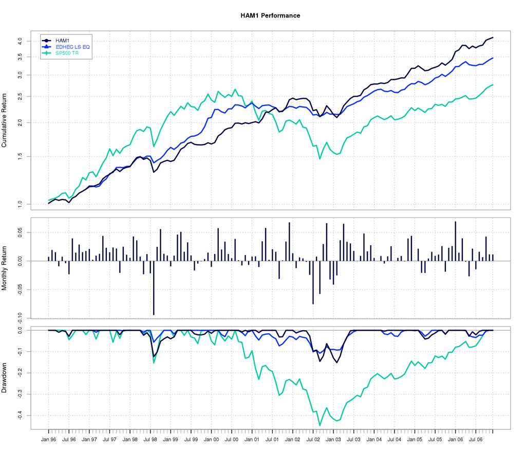

Wealth index chart, bars for per-period performance, and underwater chart generated in a single plotting window by PerformanceAnalytics

```r
charts.PerformanceSummary(managers[,c(manager.col,indexes.cols)],
                          colorset=rich6equal, lwd=2, ylog=TRUE)
```

Now, we will follow the call stack to see what functions are being used to render this plot. When following the call stack, we will show each function followed by a portion of its definition.

1. `charts.PerformanceSummary`

```r
function (R, Rf = 0, main = NULL, geometric = TRUE,  ...)
{
    ...

    chart.CumReturns(x, main = main, xaxis = FALSE, legend.loc = legend.loc,
        event.labels = event.labels, ylog = ylog, wealth.index = wealth.index,
        begin = begin, geometric = geometric, ylab = "Cumulative Return",
        ...)

    ...
}

<environment: namespace:PerformanceAnalytics>
```

2. `charts.CumReturns`

```r
function (R, wealth.index = FALSE, geometric = TRUE, ...)
{
    ...

    chart.TimeSeries(Return.cumulative, colorset = colorset,
        legend.loc = legend.loc, ...)
}
```

3. `chart.TimeSeries`

```r
chart.TimeSeries
```

```r
function (R, auto.grid = TRUE, xaxis = TRUE, yaxis = TRUE, ...)
{
    ....

    for (column in columns:1) {
        lines(1:rows, y[, column], col = colorset[column], lwd = lwd[column],
            pch = pch[column], lty = lty[column], type = type,
            ...)
    }

    ...
}
<environment: namespace:PerformanceAnalytics>
```

`lines` in Base R is used to render the cumulative returns chart. A similar approach is used in the `timeSeries` package (https://cran.r-project.org/web/packages/timeSeries/vignettes/timeSeriesPlot.pdf)

# Alternate Implementation

In this section, we attempt to reproduce the cumulative returns plot by using `xts::plot.xts` exclusively. We will omit several aspects of the original plot for the sake of brevity, such as adding a legend and fixing axes This document was knit with `RMarkdown`, so the `managers` data set in `PerformanceAnalytics` is already in memory.

```r
library(xts)
library(PerformanceAnalytics)
```

We create a new object, `x`, by subsetting a few columns of `managers`. `HAM1`, `HAM3`, and `HAM4` are now present in `x`. Note, I just picked three arbitrary variables to plot.

```r
x <- managers[,c(1, 3, 4)]
```

Next, we define a function to plot the cumulative returns of each time series. This function is written to deal with the example case in `PerformanceAnalytics` exclusively. A real implementation of this function would have to handle other cases, such as when `x` only inherits from `xts`. Tests would also have to be written with `testthat`.

```r
#' Plot a line graph of cumulative returns for an xts object with one or more variables
#'
#' @importFrom xts as.xts plot.xts
#' @param x An object that inherits from xts and zoo
#' @return Line graph for a time series object of one or more variables
#' @export plotCumReturns

chartCumReturns <- function(x) {
  stopifnot(inherits(x, c("xts", "zoo")))

  x <- xts::as.xts(apply(x, 2, function(y) (cumprod(1 + y))))
  xts::plot.xts(x = x, main = "Cumulative Returns",
                xlab = "Date", ylab = "Returns")
}
```

Call `chartCumReturns` and pass our `xts` object as an argument.

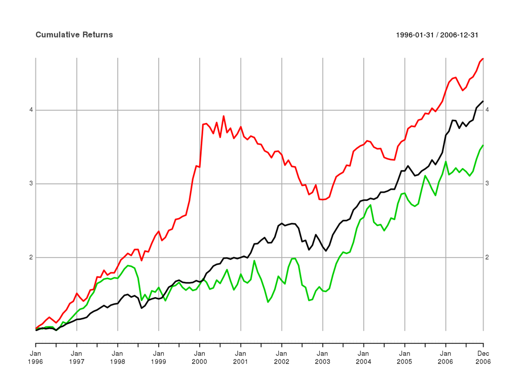

```r
chartCumReturns(x)
```

`lines` still may be called, but `xts::plot.xts` does that under the hood. Once again, this is a very minimal implementation of the original function. The purpose of this exercise was to reproduce the main logic in the `PerformanceAnalytics` function. Obviously, our alternate implementation would have to be generalized for the end user.